# assignment_2

sai sree pulimamidi

2022-10-26

*Loading all the required packages*

```r
library("VIM")
library("ISLR")
library("caret")
```

```r
library("class")
library("e1071")
library("ggplot2")
library("corrplot")
library("dplyr")
```

*Setting up working directory and loading data*

```r
online_retail <- read.csv("C:/Users/sudhakar/Downloads/Online_Retail (1).csv")
```

```r
data_country <- as.data.frame(table(online_retail$Country))

data_country$Percentage <- data_country$Freq/nrow(online_retail) * 100

colnames(data_country) <- c("Country", "Count", "Percentage")

data_country[data_country$Percentage > 1,]
```

```
##           Country  Count Percentage
## 11           EIRE   8196   1.512431
## 14         France   8557   1.579047
## 15        Germany   9495   1.752139
## 36 United Kingdom 495478  91.431956
```

*Countries accounting for more than 1% of the total transactions are EIRE, France, Germany and United Kingdom.* /vspace{1mm}/newline

*2. Adding new attribute “TransactionValue” which is the product of Quantity and UnitPrice*

```r
online_retail$TransactionValue <- online_retail$Quantity * online_retail$UnitPrice
```

*By adding this new attribute we can now calculate the value of the transactions based on our requirement.* /vspace{1mm}/newline

*3. Using the newly created variable, TransactionValue, showing the breakdown of transaction values by countries with total transaction exceeding 130,000 British Pound*

```r
online_retail %>% select(TransactionValue,Country) %>% group_by(Country) %>% summarise(Total = sum(TransactionValue)) %>% filter(Total >= 130000) %>% arrange((desc(Total)))
```

```
## # A tibble: 6 × 2
##   Country           Total
##   <chr>             <dbl>
## 1 United Kingdom 8187806.
## 2 Netherlands     284662.
## 3 EIRE            263277.
## 4 Germany         221698.
## 5 France          197404.
## 6 Australia       137077.
```

*There are total 6 countries where the transaction value exceeds 130,000 British Pound and the highest among them is “United Kingdom”.* /vspace{1mm}/newline

*4. Converting Invoice Date into a POSIXlt object*

```r
Temp=strptime(online_retail$InvoiceDate,format='%m/%d/%Y %H:%M',tz='GMT')
head(Temp)
```

```
## [1] "2010-12-01 08:26:00 GMT" "2010-12-01 08:26:00 GMT"
## [3] "2010-12-01 08:26:00 GMT" "2010-12-01 08:26:00 GMT"
## [5] "2010-12-01 08:26:00 GMT" "2010-12-01 08:26:00 GMT"
```

```r
#New_Invoice_Date
online_retail$New_Invoice_Date <- as.Date(Temp)

online_retail$New_Invoice_Date[20000]- online_retail$New_Invoice_Date[10]
```

```
## Time difference of 8 days
```

```r
#Invoice_Day_Week
online_retail$Invoice_Day_Week= weekdays(online_retail$New_Invoice_Date)

#New_Invoice_Hour
online_retail$New_Invoice_Hour = as.numeric(format(Temp, "%H"))

#New_Invoice_Month
online_retail$New_Invoice_Month = as.numeric(format(Temp, "%m"))
```

*4(a). Percentage of transactions (by numbers) by days of the week*

```r
online_retail %>% group_by(Invoice_Day_Week) %>% summarise(count=n()) %>% mutate(percentage=count/nrow(online_retail)*100)
```

```
## # A tibble: 6 × 3
##   Invoice_Day_Week  count percentage
##   <chr>             <int>      <dbl>
## 1 Friday            82193       15.2
## 2 Monday            95111       17.6
## 3 Sunday            64375       11.9
## 4 Thursday         103857       19.2
## 5 Tuesday          101808       18.8
## 6 Wednesday         94565       17.5
```

*4(b). Percentage of transactions (by transaction volume) by days of the week*

```r
online_retail %>% group_by(Invoice_Day_Week) %>% summarise(Total = sum(TransactionValue)) %>% mutate(Percentage = Total/sum(Total)*100)
```

```
## # A tibble: 6 × 3
##   Invoice_Day_Week    Total Percentage
##   <chr>               <dbl>      <dbl>
## 1 Friday           1540611.      15.8
## 2 Monday           1588609.      16.3
## 3 Sunday            805679.       8.27
## 4 Thursday         2112519       21.7
## 5 Tuesday          1966183.      20.2
## 6 Wednesday        1734147.      17.8
```

*4(c). Percentage of transactions (by transaction volume) by month of the year*

```r
online_retail %>% group_by(New_Invoice_Month) %>% summarise(Total = sum(TransactionValue)) %>% mutate(Percentage = Total/sum(Total) * 100)
```

```
## # A tibble: 12 × 3
##    New_Invoice_Month    Total Percentage
##                <dbl>    <dbl>      <dbl>
##  1                 1  560000.       5.74
##  2                 2  498063.       5.11
##  3                 3  683267.       7.01
##  4                 4  493207.       5.06
##  5                 5  723334.       7.42
##  6                 6  691123.       7.09
##  7                 7  681300.       6.99
##  8                 8  682681.       7.00
##  9                 9 1019688.      10.5
## 10                10 1070705.      11.0
## 11                11 1461756.      15.0
## 12                12 1182625.      12.1
```

*4(d). The date with the highest number of transactions from Australia*

```r
online_retail %>% filter(Country =="Australia") %>% group_by(New_Invoice_Date) %>% summarise(Total_Count = n()) %>% arrange((desc(Total_Count)))
```

```
## # A tibble: 49 × 2
##    New_Invoice_Date Total_Count
##    <date>                 <int>
##  1 2011-06-15               139
##  2 2011-07-19               137
##  3 2011-08-18                97
##  4 2011-03-03                84
##  5 2011-10-05                82
##  6 2011-05-17                73
##  7 2011-02-15                69
##  8 2011-01-06                48
##  9 2011-07-14                35
## 10 2011-09-16                34
## # … with 39 more rows
```

*As we can see from above on 2011-06-15 Australia has recorded the highest number of transactions i.e. 139 Transactions.* /vspace{1mm}/newline

*5. Plot the histogram of transaction values from Germany*

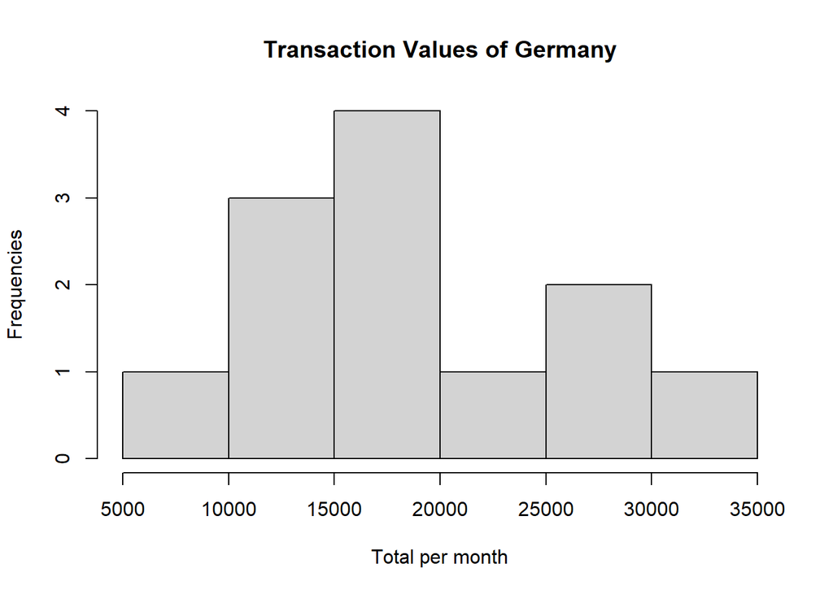

```r
Germany <- online_retail %>% filter(Country == "Germany") %>% group_by(New_Invoice_Month) %>% summarise(Total=sum(TransactionValue))

hist(Germany$Total, main = "Transaction Values of Germany", xlab="Total per month", ylab="Frequencies")
```

*6(a). Customer who had highest number of transactions*

```r
online_retail %>% group_by(CustomerID) %>% select(CustomerID) %>% filter(!is.na(CustomerID)) %>% summarise(n_count = n()) %>% arrange((desc(n_count)))
```

```
## # A tibble: 4,372 × 2
##    CustomerID n_count
##         <int>   <int>
##  1      17841    7983
##  2      14911    5903
##  3      14096    5128
##  4      12748    4642
##  5      14606    2782
##  6      15311    2491
##  7      14646    2085
##  8      13089    1857
##  9      13263    1677
## 10      14298    1640
## # … with 4,362 more rows
```

*The CustomerID 17841 had the highest number of transactions amongst others with a total of 7983 transactions.* /vspace{1mm}/newline

*6(b). Most valuable customer with the highest total sum of transactions*

```r
online_retail %>% group_by(CustomerID) %>% select(CustomerID, TransactionValue) %>% filter(!is.na(CustomerID)) %>% summarise(Spending_max = sum(TransactionValue)) %>% arrange((desc(Spending_max)))
```

```
## # A tibble: 4,372 × 2
##    CustomerID Spending_max
##         <int>        <dbl>
##  1      14646      279489.
##  2      18102      256438.
##  3      17450      187482.
##  4      14911      132573.
##  5      12415      123725.
##  6      14156      113384.
##  7      17511       88125.
##  8      16684       65892.
##  9      13694       62653.
## 10      15311       59419.
## # … with 4,362 more rows
```

*The CustomerID 14646 is the most valuable customer with the highest spending sum of 279,489.020 British Sterling Pound.* /vspace{1mm}/newline

*7. Percentage of missing values for each variable in the dataset*

```r
colMeans(is.na(online_retail)*100)
```

```
##         InvoiceNo         StockCode       Description          Quantity
##           0.00000           0.00000           0.00000           0.00000
##       InvoiceDate         UnitPrice        CustomerID           Country
##           0.00000           0.00000          24.92669           0.00000
##  TransactionValue  New_Invoice_Date  Invoice_Day_Week  New_Invoice_Hour
##           0.00000           0.00000           0.00000           0.00000
## New_Invoice_Month
##           0.00000
```

*We can observe that CustomerID is the only attribute with 24.9266% of NAs in the entire dataset.* /vspace{1mm}/newline

*8. The number of transactions with missing CustomerID records by Countries*

```r
online_retail %>% filter(is.na(CustomerID)) %>% group_by(Country) %>% count()
```

```
## # A tibble: 9 × 2
## # Groups:   Country [9]
##   Country             n
##   <chr>           <int>
## 1 Bahrain             2
## 2 EIRE              711
## 3 France             66
## 4 Hong Kong         288
## 5 Israel             47
## 6 Portugal           39
## 7 Switzerland       125
## 8 United Kingdom 133600
## 9 Unspecified       202
```

*There are in total 8 countries and 1 unspecified country in the entire dataset which has NA values in them amongst these United Kingdom is the country with highest NA records of 133,600 rows.* /vspace{1mm}/newline

*9. On average, how often the costumers comeback to the website for their next shopping?*

```r
Diff_Days <- online_retail %>% select(CustomerID,New_Invoice_Date) %>% group_by(CustomerID) %>% distinct(New_Invoice_Date) %>% arrange(desc(CustomerID)) %>%  mutate(Days_Between = New_Invoice_Date-lag(New_Invoice_Date)) %>% filter(!is.na(Days_Between))

Diff_Days
```

```
## # A tibble: 15,200 × 3
## # Groups:   CustomerID [2,992]
##    CustomerID New_Invoice_Date Days_Between
##         <int> <date>           <drtn>
##  1      18287 2011-10-12       143 days
##  2      18287 2011-10-28        16 days
##  3      18283 2011-01-23        17 days
##  4      18283 2011-02-28        36 days
##  5      18283 2011-04-21        52 days
##  6      18283 2011-05-23        32 days
##  7      18283 2011-06-14        22 days
##  8      18283 2011-06-23         9 days
##  9      18283 2011-07-14        21 days
## 10      18283 2011-09-05        53 days
## # … with 15,190 more rows
```

```r
mean(Diff_Days$Days_Between)
```

```
## Time difference of 38.4875 days
```

*On an average approximately for every 38 days customers come back to the website for their next shopping.* /vspace{1mm}/newline

*10. Return rate of goods purchased by the customers from France*

```r
F_Cancel <- online_retail %>% filter(Country=="France",Quantity<0) %>% count()

F_Total <- online_retail %>% filter(Country=="France") %>% count()

Return_Percentage_France <- F_Cancel/F_Total*100
Return_Percentage_France
```

```
##          n
## 1 1.741264
```

*The return rate of customers who made purchases in France is 1.741264%.* /vspace{1mm}/newline

*11. The product that has generated the highest revenue for the retailer*

```r
online_retail %>% select(StockCode,TransactionValue) %>% group_by(StockCode) %>%  summarise(Total=sum(TransactionValue)) %>% arrange((desc(Total)))
```

```
## # A tibble: 4,070 × 2
##    StockCode   Total
##    <chr>       <dbl>
##  1 DOT       206245.
##  2 22423     164762.
##  3 47566      98303.
##  4 85123A     97894.
##  5 85099B     92356.
##  6 23084      66757.
##  7 POST       66231.
##  8 22086      63792.
##  9 84879      58960.
## 10 79321      53768.
## # … with 4,060 more rows
```

*The product with the StockCode as “DOT” is the one which has generated highest revenue to the retailer i.e. 206,245.48 British Sterling Pound.* /vspace{1mm}/newline

*12. Unique Customers in the dataset*

```r
online_retail %>% select(CustomerID) %>% unique() %>% count()
```

```
##      n
## 1 4373
```